# Check the Potr genomes gene overlap, pairwise, with one-way 70% coverage

Nicolas Delhomme

2015-08-21

# 1 Setup

Set the working dir

```r
setwd("/mnt/picea/projects/aspseq/asp201/rna/BEDTools/")
```

Load libraries

```r
suppressPackageStartupMessages(library(Biostrings))
suppressPackageStartupMessages(library(genomeIntervals))
suppressPackageStartupMessages(library(igraph))
suppressPackageStartupMessages(library(matrixStats))
suppressPackageStartupMessages(library(pander))
suppressPackageStartupMessages(library(parallel))
suppressPackageStartupMessages(library(RColorBrewer))
suppressPackageStartupMessages(library(S4Vectors))
suppressPackageStartupMessages(library(VennDiagram))
```

Source helpers

```r
source("~/Git/UPSCb/src/R/gff3Utilities.R")
source("~/Git/UPSCb/src/R/plot.multidensity.R")
```

Graphic params

```r
mar <- par("mar")
pal <- brewer.pal(8,"Dark2")
```

# 2 Analysis

Reading in all the pairwise intersect data

```r
res <- mclapply(dir(".",pattern=".*-70p\\.tsv"),read.delim,
                stringsAsFactors=FALSE,header=FALSE,mc.cores=6L)

names(res) <- sub("-70p\\.tsv","",dir(".",pattern=".*-70p\\.tsv"))
```

Reading in all the complete gmap gff3 files

```r
gff3s <- mclapply(dir("../gmap/Potr",pattern=".*\\.gff3",full.names = TRUE),readGff3,mc.cores=6L)
names(gff3s) <- sub("\\.gff3","",dir("../gmap/Potr",pattern=".*\\.gff3"))
```

## 2.1 GFF3

Create a list of IDs

```r
ID.list <- lapply(lapply(res,"[[",18),function(v){gsub("ID=|;.*","",v[v!="."])})
save(ID.list,file="potrOvl70pGmapIDList.rda")
```

Barplot the paths

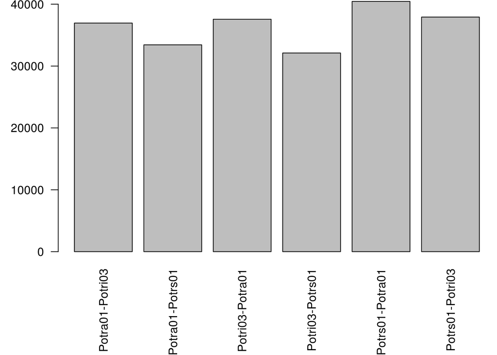

```r
par(mar=c(7.1,4.1,0.1,0.1))
barplot(elementLengths(ID.list),las=2)
```

```r
par(mar=mar)
```

Check the genes

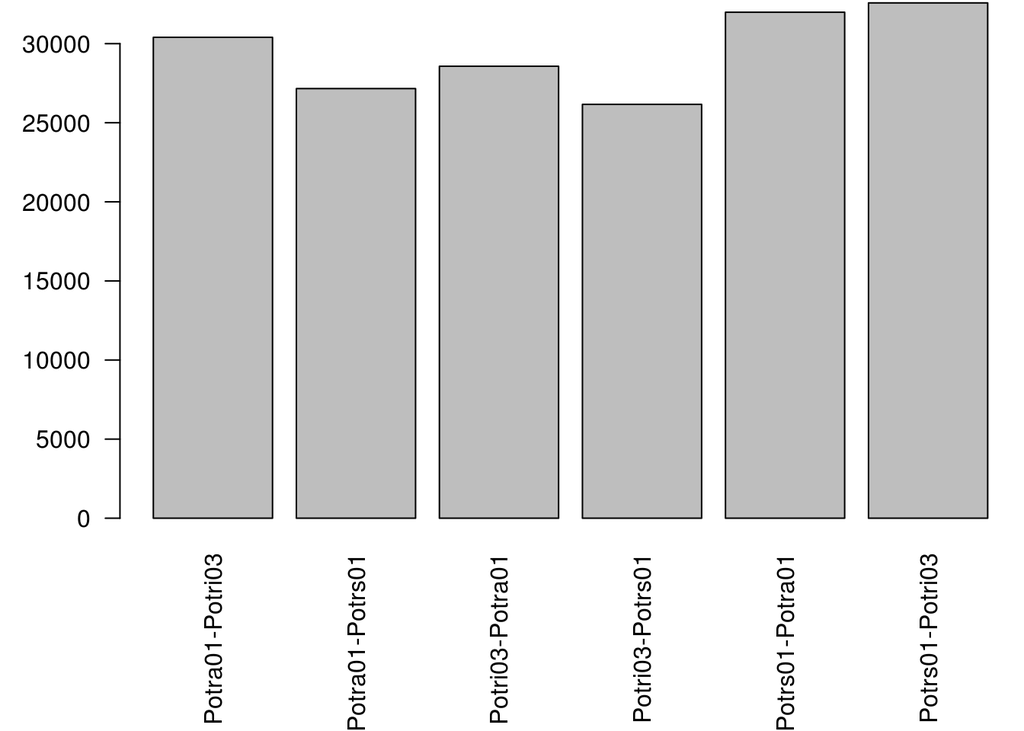

```r
par(mar=c(7.1,4.1,0.1,0.1))
barplot(elementLengths(sapply(lapply(ID.list,function(IDl){sub("\\.0\\.path.*","",IDl)}),unique)),las=2)
```

```r
par(mar=mar)
```

Quantify the paths Most of them have unique paths

```r
pander(do.call(rbind,lapply(ID.list,function(ls){table(sub(".*.path","",ls))})))
```

|  | 1 | 2 | 3 | 4 | 5 |
| --- | --- | --- | --- | --- | --- |
| **Potra01-Potri03** | 33089 | 3114 | 513 | 171 | 63 |
| **Potra01-Potrs01** | 28610 | 2704 | 878 | 673 | 566 |
| **Potri03-Potra01** | 33282 | 3212 | 671 | 263 | 139 |
| **Potri03-Potrs01** | 28676 | 2598 | 502 | 223 | 112 |
| **Potrs01-Potra01** | 33544 | 4832 | 974 | 590 | 511 |
| **Potrs01-Potri03** | 33223 | 3885 | 552 | 191 | 67 |

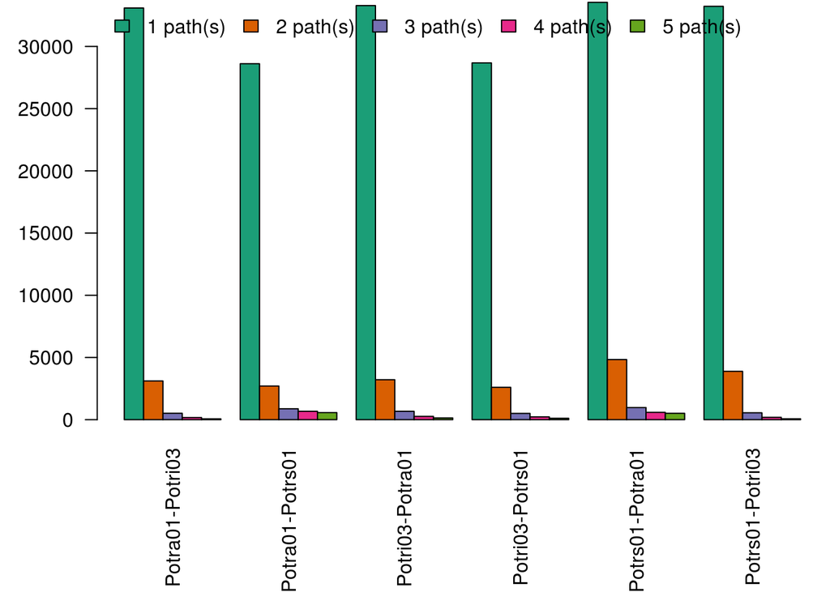

```r
par(mar=c(7.1,4.1,0.1,0.1))
barplot(t(do.call(rbind,lapply(ID.list,function(ls){table(sub(".*.path","",ls))}))),beside=TRUE,las=2,
        col=pal[1:5])
legend("topleft",legend=paste(1:5,"path(s)"),fill=pal[1:5],horiz=TRUE,bty="n",yjust=1)
```

```r
par(mar=mar)
```

Get the sub gffs

```r
stopifnot(names(gff3s) == names(ID.list))
sgff3 <- mcmapply(extractFromGff3UsingGeneIDs,gff3s,ID.list,mc.cores=6L)

cov.idt <- mclapply(sgff3,function(gff){
  t(apply(getGffAttribute(gff[gff$type=="mRNA",],c("coverage","identity")),1,as.numeric))
},mc.cores=6L)
```

This is pretty cool

1. Potrs and Potra are very similar and some genes seem to be extremely conserved, otherwise the peaks peak around 98-99%
2. Potri aligned to Potra or Potrs show very similar curves (first and last), which is a good validation
3. Potra and Potrs and aligned to Potri show a different story, which might be interesting. Potra has less identity to Potri than Potrs has. Either this is due to the lower quality (or higher hererozygousity) of the Potra assembly or it starts to show the fact that Potri and Potrs are closer environmentally and that Potra and Potrs have started to drift away, influenced by the continental environment

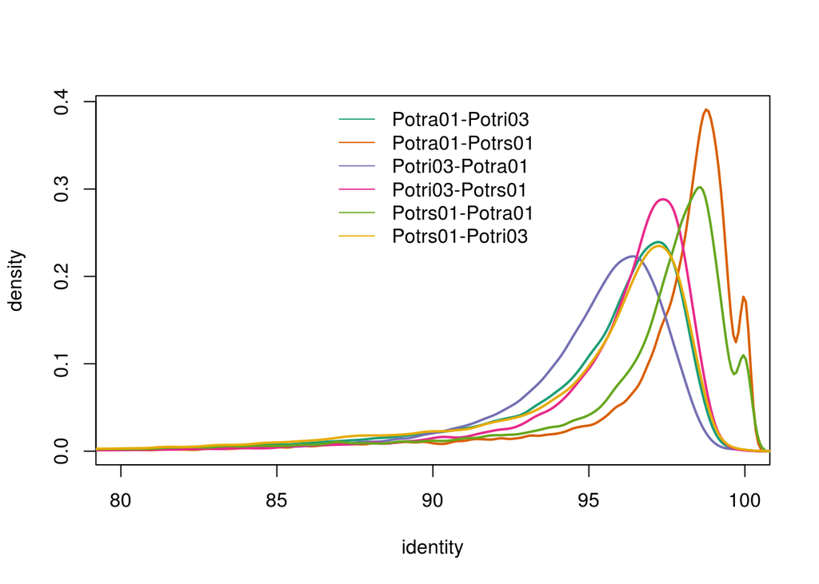

```r
plot.multidensity(lapply(cov.idt,function(m){m[,2]}),xlab="identity",lwd=2,xlim=c(80,100))
```

Most of the path have a full coverage

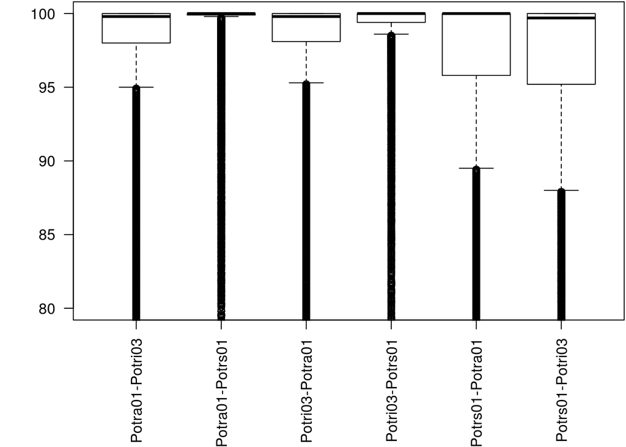

```r
par(mar=c(7.1,4.1,0.1,0.1))
boxplot(lapply(cov.idt,function(m){m[,1]}),ylim=c(80,100),las=2)
```

```r
par(mar=mar)
```

## 2.2 Graphs

Create a list of edges

```r
edges.list <- lapply(res,"[",c(9,18))
edges.list <- lapply(edges.list,function(edges){
  cbind(gsub("ID=|;.*","",edges[,1]),
        gsub(".*Name=|\\.0$","",edges[,2]))})
```

Report on the number of links and the number of missing

```r
stats <- do.call(rbind,lapply(edges.list,function(edges){
  tab <- table(table(edges[,2]))
  mult <- rep(as.integer(names(tab[-c(1,length(tab))])),tab[-c(1,length(tab))])
  c(total=nrow(edges),
    gene=length(unique(edges[,1])),
    gene.mapped=length(unique(edges[,2]))-1,
    gene.unique.mapped=sum(table(edges[,2])==1),
    gene.multi=sum(table(edges[,2])>1) - 1,
    gene.multi.mean=mean(mult),
    gene.multi.median=median(mult),
    gene.multi.sd=sd(mult),
    gene.multi.min=min(mult),
    gene.multi.max=max(mult),
    gene.missed=sum(edges[,2]==".")
    )
}))
```

Print it

```r
pander(stats)
```

Table continues below

|  | total | gene | gene.mapped |
| --- | --- | --- | --- |
| **Potra01-Potri03** | 44201 | 36322 | 30400 |
| **Potra01-Potrs01** | 42233 | 36322 | 27159 |
| **Potri03-Potra01** | 47404 | 41335 | 28570 |
| **Potri03-Potrs01** | 45540 | 41335 | 26163 |
| **Potrs01-Potra01** | 45026 | 37928 | 31986 |
| **Potrs01-Potri03** | 45225 | 37928 | 32576 |

Table continues below

|  | gene.unique.mapped | gene.multi |
| --- | --- | --- |
| **Potra01-Potri03** | 26642 | 3758 |
| **Potra01-Potrs01** | 23505 | 3654 |
| **Potri03-Potra01** | 24141 | 4429 |
| **Potri03-Potrs01** | 23066 | 3097 |
| **Potrs01-Potra01** | 26157 | 5829 |
| **Potrs01-Potri03** | 28471 | 4105 |

Table continues below

|  | gene.multi.mean | gene.multi.median |
| --- | --- | --- |
| **Potra01-Potri03** | 2.743 | 2 |
| **Potra01-Potrs01** | 2.716 | 2 |
| **Potri03-Potra01** | 3.031 | 2 |
| **Potri03-Potrs01** | 2.921 | 2 |
| **Potrs01-Potra01** | 2.452 | 2 |
| **Potrs01-Potri03** | 2.301 | 2 |

Table continues below

|  | gene.multi.sd | gene.multi.min |
| --- | --- | --- |
| **Potra01-Potri03** | 5.124 | 2 |
| **Potra01-Potrs01** | 2.19 | 2 |
| **Potri03-Potra01** | 2.532 | 2 |
| **Potri03-Potrs01** | 2.27 | 2 |
| **Potrs01-Potra01** | 0.9469 | 2 |
| **Potrs01-Potri03** | 0.7302 | 2 |

|  | gene.multi.max | gene.missed |
| --- | --- | --- |
| **Potra01-Potri03** | 97 | 7251 |
| **Potra01-Potrs01** | 94 | 8802 |
| **Potri03-Potra01** | 44 | 9837 |
| **Potri03-Potrs01** | 33 | 13429 |
| **Potrs01-Potra01** | 14 | 4575 |
| **Potrs01-Potri03** | 10 | 7307 |

Graph the edges list

```r
edges.graf <- lapply(lapply(edges.list,function(edges){edges[edges[,2]!=".",]}),
                      graph.edgelist,directed=FALSE)
```

Get their stats

```r
graf.stats <- do.call(rbind,lapply(edges.graf,function(graf){
  cl <- clusters(graf)
  c(clusters=cl$no,
    singleton=sum(cl$csize==2),
    multiple=length(cl$csize[cl$csize>2]),
    mean=mean(cl$csize[cl$csize>2]-1),
    median=median(cl$csize[cl$csize>2]-1),
    sd=sd(cl$csize[cl$csize>2]-1),
    min=min(cl$csize[cl$csize>2]-1),
    max=max(cl$csize[cl$csize>2]-1))
}))
```

And print them

```r
pander(graf.stats)
```

Table continues below

|  | clusters | singleton | multiple | mean |
| --- | --- | --- | --- | --- |
| **Potra01-Potri03** | 25461 | 21436 | 4025 | 3.124 |
| **Potra01-Potrs01** | 24033 | 20733 | 3300 | 3.004 |
| **Potri03-Potra01** | 25081 | 21040 | 4041 | 3.451 |
| **Potri03-Potrs01** | 23554 | 20308 | 3246 | 3.144 |
| **Potrs01-Potra01** | 27577 | 22341 | 5236 | 2.945 |
| **Potrs01-Potri03** | 26760 | 21606 | 5154 | 2.878 |

|  | median | sd | min | max |
| --- | --- | --- | --- | --- |
| **Potra01-Potri03** | 2 | 3.994 | 2 | 111 |
| **Potra01-Potrs01** | 2 | 3.773 | 2 | 95 |
| **Potri03-Potra01** | 2 | 6.562 | 2 | 173 |
| **Potri03-Potrs01** | 2 | 5.645 | 2 | 173 |
| **Potrs01-Potra01** | 2 | 3.104 | 2 | 98 |
| **Potrs01-Potri03** | 2 | 3.244 | 2 | 100 |

Combined graph

```r
all.edges <- do.call(rbind,
                     lapply(edges.list,
                            function(edges){edges[edges[,2]!=".",]}))
graf <- graph.edgelist(all.edges)
```

Look at the clusters

```r
cl <- clusters(graf)
sprintf("There are %s clusters",cl$no)
```

```
## [1] "There are 25600 clusters"
```

and the table of the cluster sizes

```r
pander(sort(table(cl$csize),decreasing=TRUE),
       caption="Occurence (upper row) of the different cluster sizes (lower row)")
```

Table continues below

| 3 | 4 | 5 | 6 | 2 | 7 | 8 | 9 | 10 | 11 |
| --- | --- | --- | --- | --- | --- | --- | --- | --- | --- |
| 16459 | 3452 | 1333 | 1286 | 1093 | 645 | 350 | 213 | 134 | 93 |

Table continues below

| 12 | 13 | 15 | 14 | 16 | 17 | 20 | 23 | 18 | 19 |
| --- | --- | --- | --- | --- | --- | --- | --- | --- | --- |
| 75 | 59 | 38 | 36 | 32 | 25 | 22 | 18 | 17 | 17 |

Table continues below

| 22 | 21 | 25 | 26 | 24 | 31 | 27 | 28 | 30 | 37 |
| --- | --- | --- | --- | --- | --- | --- | --- | --- | --- |
| 13 | 11 | 10 | 9 | 8 | 8 | 7 | 6 | 6 | 6 |

Table continues below

| 32 | 40 | 44 | 33 | 35 | 38 | 42 | 49 | 57 | 29 |
| --- | --- | --- | --- | --- | --- | --- | --- | --- | --- |
| 5 | 5 | 5 | 4 | 4 | 4 | 4 | 4 | 4 | 3 |

Table continues below

| 34 | 36 | 39 | 41 | 43 | 45 | 50 | 52 | 56 | 71 |
| --- | --- | --- | --- | --- | --- | --- | --- | --- | --- |
| 3 | 3 | 3 | 3 | 3 | 3 | 3 | 3 | 3 | 3 |

Table continues below

| 46 | 51 | 54 | 55 | 59 | 61 | 68 | 70 | 75 | 81 |
| --- | --- | --- | --- | --- | --- | --- | --- | --- | --- |
| 2 | 2 | 2 | 2 | 2 | 2 | 2 | 2 | 2 | 2 |

Table continues below

| 126 | 47 | 48 | 53 | 58 | 63 | 65 | 67 | 69 |
| --- | --- | --- | --- | --- | --- | --- | --- | --- |
| 2 | 1 | 1 | 1 | 1 | 1 | 1 | 1 | 1 |

Table continues below

| 72 | 85 | 87 | 94 | 95 | 102 | 113 | 116 | 117 |
| --- | --- | --- | --- | --- | --- | --- | --- | --- |
| 1 | 1 | 1 | 1 | 1 | 1 | 1 | 1 | 1 |

| 119 | 122 | 144 | 222 | 263 | 604 | 663 | 2998 |
| --- | --- | --- | --- | --- | --- | --- | --- |
| 1 | 1 | 1 | 1 | 1 | 1 | 1 | 1 |

Draw some examples

Not the one with the max vertices - 2998! - as it is not relevant An example with 3 (the most frequent)

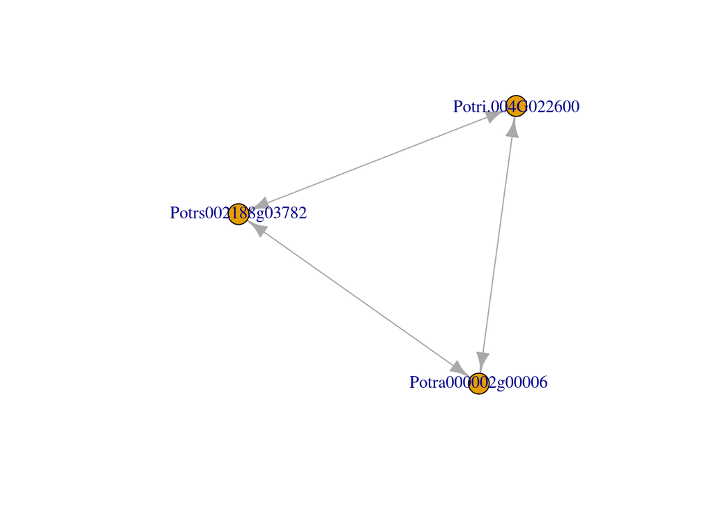

```r
baron <- induced.subgraph(graf,get.vertex.attribute(graf,"name")[which(clusters(graf)$membership == which(clusters(graf)$csize==3)[1])])
plot.igraph(baron)
```

An example with 2

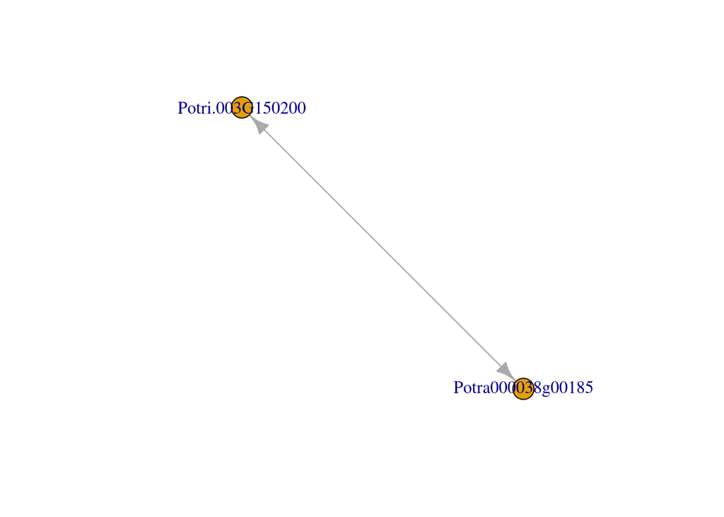

```r
baron <- induced.subgraph(graf,get.vertex.attribute(graf,"name")[which(clusters(graf)$membership == which(clusters(graf)$csize==2)[1])])
plot.igraph(baron)
```

An example with 4

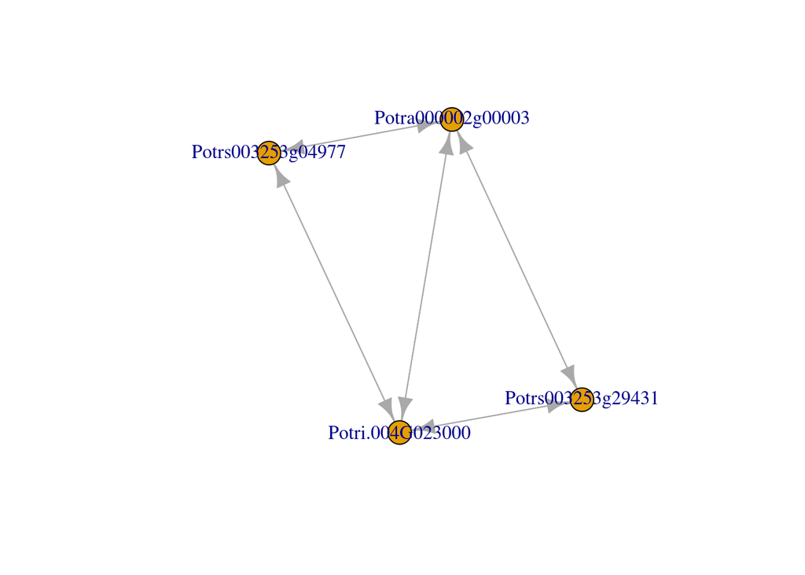

```r
baron <- induced.subgraph(graf,get.vertex.attribute(graf,"name")[which(clusters(graf)$membership == which(clusters(graf)$csize==4)[1])])
plot.igraph(baron)
```

An example with 5

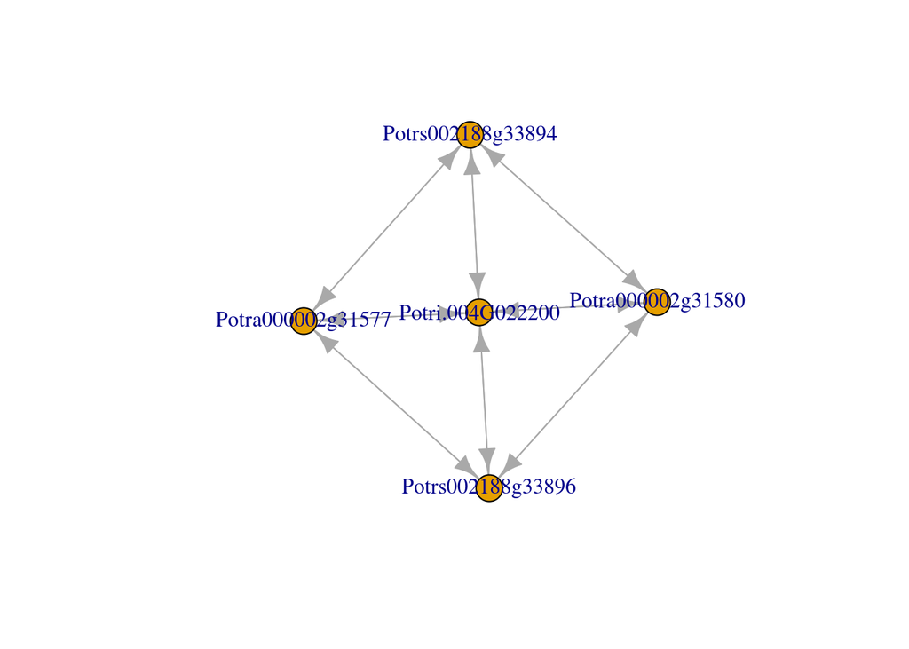

```r
baron <- induced.subgraph(graf,get.vertex.attribute(graf,"name")[which(clusters(graf)$membership == which(clusters(graf)$csize==5)[1])])
plot.igraph(baron)
```

An example with 6

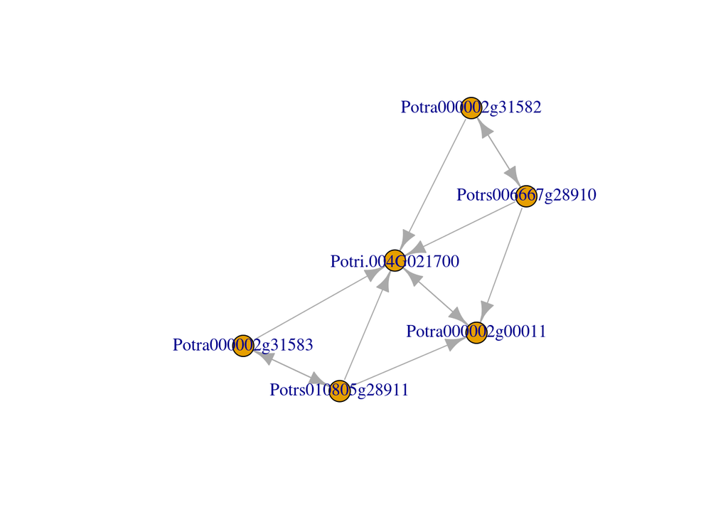

```r
baron <- induced.subgraph(graf,get.vertex.attribute(graf,"name")[which(clusters(graf)$membership == which(clusters(graf)$csize==6)[1])])
plot.igraph(baron,layout=layout.spring(baron))
```

## 2.3 Intersects

This all looks good, let’s count the number of clusters and how many species are involved in each

```r
cluster.members.mat <- do.call(rbind,lapply(lapply(lapply(split(get.vertex.attribute(graph = graf,name="name"),
                                         clusters(graf)$membership),substr,1,5),
                            factor,levels=c("Potra","Potri","Potrs")),table))
```

How does this look as a venn diagram?

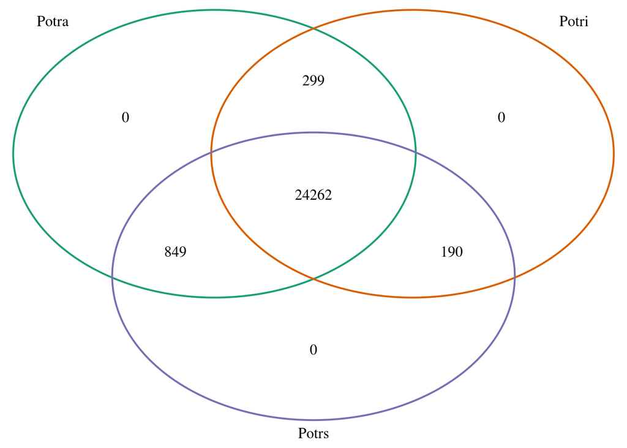

```r
plot.new()
grid.draw(venn.diagram(
  lapply(1:3,function(i,dat){which(dat[,i])},cluster.members.mat > 0),
  filename=NULL,
  col=pal[1:3],
  category.names = colnames(cluster.members.mat)
))
```

### 2.3.1 Clusters

Cluster numbers:

```r
nrow(cluster.members.mat)
```

```
## [1] 25600
```

Number of genes per species

```r
pander(colSums(cluster.members.mat))
```

| Potra | Potri | Potrs |
| --- | --- | --- |
| 35504 | 37840 | 36426 |

Number of “absent” gene per species

```r
pander(colSums(cluster.members.mat==0))
```

| Potra | Potri | Potrs |
| --- | --- | --- |
| 190 | 849 | 299 |

Occurence of the missing genes - as expected one species only is missing in 1338 cases

```r
pander(table(rowSums(cluster.members.mat==0)))
```

| 0 | 1 |
| --- | --- |
| 24262 | 1338 |

Number of unique genes per cluster

```r
pander(table(rowSums(cluster.members.mat==1)))
```

| 0 | 1 | 2 | 3 |
| --- | --- | --- | --- |
| 2900 | 1643 | 4759 | 16298 |

Number of identical number of genes per cluster

```r
sum(rowSds(cluster.members.mat)==0)
```

```
## [1] 17429
```

And their occurences, i.e. the number of members per species

```r
pander(table(cluster.members.mat[rowSds(cluster.members.mat)==0,1]))
```

| 1 | 2 | 3 | 4 | 5 | 6 | 7 | 8 |
| --- | --- | --- | --- | --- | --- | --- | --- |
| 16298 | 1016 | 87 | 14 | 8 | 3 | 2 | 1 |

Number of unique gene clusters per species

```r
pander(colSums(cluster.members.mat==1))
```

| Potra | Potri | Potrs |
| --- | --- | --- |
| 20766 | 19174 | 20115 |

Number of multiple gene clusters per species It would seem like Potra is more collapsed

```r
pander(colSums(cluster.members.mat>1))
```

| Potra | Potri | Potrs |
| --- | --- | --- |
| 4644 | 5577 | 5186 |

Stats of the multiple gene clusters

```r
pander(
  data.frame(
    mean=sapply(1:3,function(i,mat){mean(mat[mat[,i]>1,i])},cluster.members.mat),
    median=sapply(1:3,function(i,mat){median(mat[mat[,i]>1,i])},cluster.members.mat),
    max=sapply(1:3,function(i,mat){max(mat[mat[,i]>1,i])},cluster.members.mat),
    min=sapply(1:3,function(i,mat){min(mat[mat[,i]>1,i])},cluster.members.mat),
    row.names=c("Potra01","Potri03","Potrs01")))
```

|  | mean | median | max | min |
| --- | --- | --- | --- | --- |
| **Potra01** | 3.174 | 2 | 844 | 2 |
| **Potri03** | 3.347 | 2 | 1273 | 2 |
| **Potrs01** | 3.145 | 2 | 881 | 2 |

Number of clusters presents in Potr[as] but not Potri

```r
Potras.clusters <- which(rowSums(cluster.members.mat[,c("Potra","Potrs")] >= 1)==2  & cluster.members.mat[,"Potri"] == 0)
length(Potras.clusters)
```

```
## [1] 849
```

Number of corresponding genes

```r
sum(clusters(graf)$csize[Potras.clusters])
```

```
## [1] 2138
```

Distribution of the cluster size

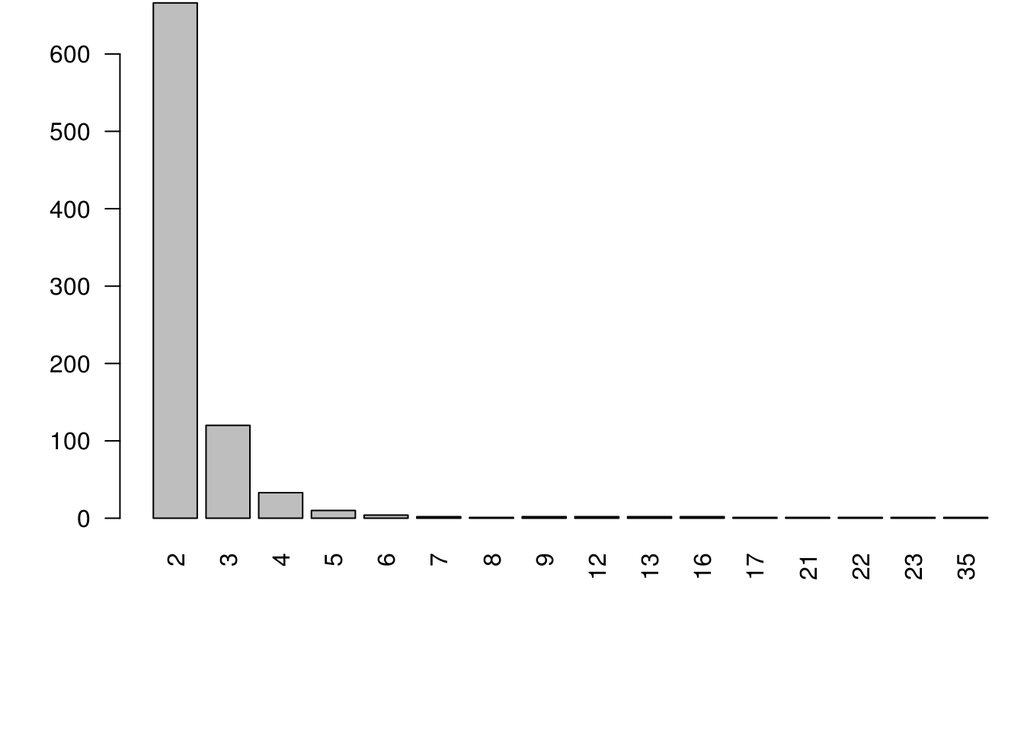

```r
par(mar=c(7.1,4.1,0.1,0.1))
barplot(table(clusters(graf)$csize[Potras.clusters]),las=2)
```

```r
par(mar=mar)
```

Check if one species has more gene than the other (pre cluster Potra - Potrs) We seem to have more copies in Potrs, so Potra appears more collapsed.

```r
pander(table(cluster.members.mat[Potras.clusters,1] - cluster.members.mat[Potras.clusters,3]))
```

| -5 | -3 | -2 | -1 | 0 | 1 | 2 | 6 |
| --- | --- | --- | --- | --- | --- | --- | --- |
| 1 | 3 | 1 | 99 | 699 | 37 | 8 | 1 |

Get the gene IDs

```r
IDs <- get.vertex.attribute(graf,"name")[which(clusters(graf)$membership %in% Potras.clusters)]
write(IDs[grep("Potra",IDs)],"Potra01-70p-Aspen-specific-IDs.txt")
write(IDs[grep("Potrs",IDs)],"Potrs01-70p-Aspen-specific-IDs.txt")
```

## 2.4 Pairwise stats

There are about the same number of Potri genes targeted by Potra/s There are however less Potra than Potrs genes in all comparisons, which might indicate 1) collapsing in Potra, 2) haplotype splitting in Potrs

```r
table(substr(get.vertex.attribute(graf,"name")[which(clusters(graf)$membership %in% which(cluster.members.mat[,"Potra"] != 0 & cluster.members.mat[,"Potri"] != 0))],1,5))[c(1,2)]
```

```
##
## Potra Potri
## 34463 37635
```

```r
table(substr(get.vertex.attribute(graf,"name")[which(clusters(graf)$membership %in% which(cluster.members.mat[,"Potrs"] != 0 & cluster.members.mat[,"Potri"] != 0))],1,5))[c(3,2)]
```

```
##
## Potrs Potri
## 35329 37488
```

```r
table(substr(get.vertex.attribute(graf,"name")[which(clusters(graf)$membership %in% which(cluster.members.mat[,"Potra"] != 0 & cluster.members.mat[,"Potrs"] != 0))],1,5))[c(1,3)]
```

```
##
## Potra Potrs
## 35181 36234
```

## 2.5 Multiple stats

This makes the same story as before. Potra/s more collapsed than Potri and Potrs less collapsed than Potra

```r
potra.sel <- cluster.members.mat[,"Potra"] == 1 & rowSums(cluster.members.mat[,-1] > 1)>=1
sum(potra.sel)
```

```
## [1] 3549
```

```r
colMeans(cluster.members.mat[potra.sel,2:3])
```

```
##    Potri    Potrs
## 1.683291 1.562412
```

```r
potri.sel <- cluster.members.mat[,"Potri"] == 1 & rowSums(cluster.members.mat[,-2] > 1)>=1
sum(potri.sel)
```

```
## [1] 2449
```

```r
colMeans(cluster.members.mat[potri.sel,c(1,3)])
```

```
##    Potra    Potrs
## 1.541445 1.795427
```

```r
potrs.sel <- cluster.members.mat[,"Potrs"] == 1 & rowSums(cluster.members.mat[,-3] > 1)>=1
sum(potrs.sel)
```

```
## [1] 2977
```

```r
colMeans(cluster.members.mat[potrs.sel,1:2])
```

```
##    Potra    Potri
## 1.473967 1.863285
```

## 2.6 Venn Diagram

We obtain from every species their synthetic transcript ID set.

```r
Potra.st <- sub("\\.0$","",names(readDNAStringSet("/mnt/picea/storage/reference/Populus-tremula/v1.0/fasta/Potra01-synthetic-transcripts.fa")))
Potri.st <- sub("\\.0$","",names(readDNAStringSet("/mnt/picea/storage/reference/Populus-trichocarpa/v3.0/fasta/Potri03-synthetic-transcripts.fa")))
Potrs.st <- sub("\\.0$","",names(readDNAStringSet("/mnt/picea/storage/reference/Populus-tremuloides/v1.0/fasta/Potrs01-synthetic-transcripts.fa")))
```

The total number of genes is:

```r
all.genes <- length(c(Potra.st,Potri.st,Potrs.st))
sprintf("The three species have a total of %s genes",all.genes)
```

```
## [1] "The three species have a total of 115585 genes"
```

Which is split into the following

```r
n1 <- sum(!Potra.st %in% unlist(all.edges))
n2 <- sum(!Potri.st %in% unlist(all.edges))
n3 <- sum(!Potrs.st %in% unlist(all.edges))
n12 <- sum(unlist(cluster.members.mat[cluster.members.mat[,"Potrs"] == 0,c("Potra","Potri")]))
n23 <- sum(unlist(cluster.members.mat[cluster.members.mat[,"Potra"] == 0,c("Potri","Potrs")]))
n13 <- sum(unlist(cluster.members.mat[cluster.members.mat[,"Potri"] == 0,c("Potra","Potrs")]))
n123 <- sum(unlist(cluster.members.mat[rowSums(cluster.members.mat == 0) == 0,]))
```

Validate

```r
vals <- c(n1,n2,n3,n12,n23,n13,n123)
stopifnot(sum(vals) == all.genes)
```

Convert into percentage

```r
vals <- round(vals / all.genes * 1000,digits=0)
```

Plot

The represented values are in thousandth (tenth of percentage). Reason is simply that VennDiagram does not deal so well with non integers.

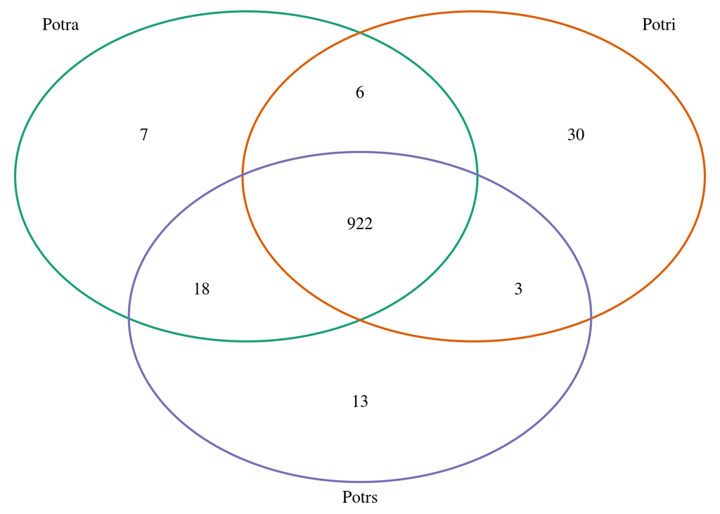

```r
plot.new()
grid.draw(
  draw.triple.venn(
  area1=vals[1] + vals[4] + vals[6] + vals[7],
  area2=vals[2] + vals[4] + vals[5] + vals[7],
  area3=vals[3] + vals[5] + vals[6] + vals[7],
  n12=vals[4] + vals[7],
  n23=vals[5] + vals[7],
  n13=vals[6] + vals[7],
  n123=vals[7],
  col=pal[1:3],
  category = colnames(cluster.members.mat),
  ind=FALSE,euler.d=FALSE,scale=FALSE
))
```

The same with the actual values

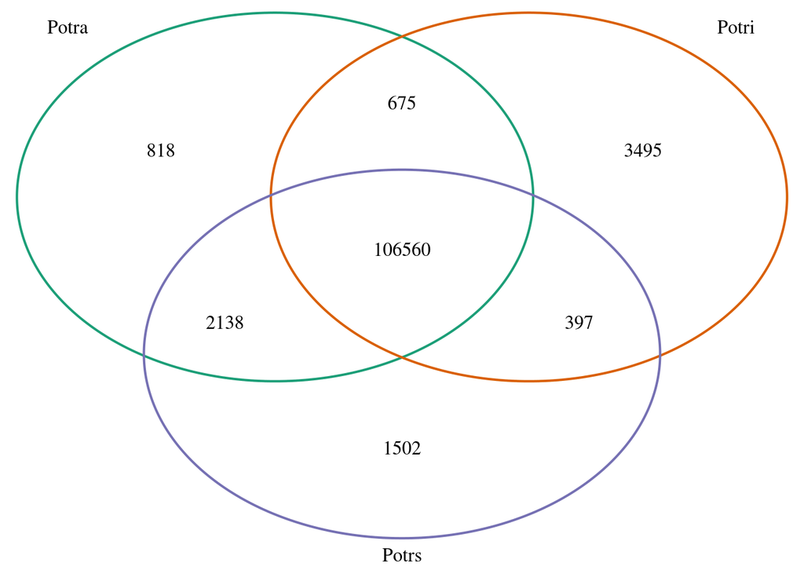

```r
plot.new()
grid.draw(
  draw.triple.venn(
    area1=n1 + n12 + n13 + n123,
    area2=n2 + n12 + n23 + n123,
    area3=n3 + n13 + n23 + n123,
    n12=n12 + n123,
    n23=n23 + n123,
    n13=n13 + n123,
    n123=n123,
    col=pal[1:3],
    category = colnames(cluster.members.mat),
    ind=FALSE,euler.d=FALSE,scale=FALSE
  ))
```

The number of genes in the different intersects

Potra + Potri

```r
sprintf("There are %s Potra and %s Potri genes in the Potra-Potri intersect",
        sum(cluster.members.mat[cluster.members.mat[,"Potrs"] == 0,"Potra"]),
        sum(cluster.members.mat[cluster.members.mat[,"Potrs"] == 0,"Potri"])
        )
```

```
## [1] "There are 323 Potra and 352 Potri genes in the Potra-Potri intersect"
```

Potra + Potrs

```r
sprintf("There are %s Potra and %s Potrs genes in the Potra-Potrs intersect",
        sum(cluster.members.mat[cluster.members.mat[,"Potri"] == 0,"Potra"]),
        sum(cluster.members.mat[cluster.members.mat[,"Potri"] == 0,"Potrs"])
)
```

```
## [1] "There are 1041 Potra and 1097 Potrs genes in the Potra-Potrs intersect"
```

Potri + Potrs

```r
sprintf("There are %s Potri and %s Potri genes in the Potri-Potrs intersect",
        sum(cluster.members.mat[cluster.members.mat[,"Potra"] == 0,"Potri"]),
        sum(cluster.members.mat[cluster.members.mat[,"Potra"] == 0,"Potrs"])
)
```

```
## [1] "There are 205 Potri and 192 Potri genes in the Potri-Potrs intersect"
```

Potra + Potri + Potrs

```r
sprintf("There are %s Potra, %s Potri and %s Potrs genes in the overall intersect",
        sum(cluster.members.mat[rowSums(cluster.members.mat==0)==0,"Potra"]),
        sum(cluster.members.mat[rowSums(cluster.members.mat==0)==0,"Potri"]),
        sum(cluster.members.mat[rowSums(cluster.members.mat==0)==0,"Potrs"])
        )
```

```
## [1] "There are 34140 Potra, 37283 Potri and 35137 Potrs genes in the overall intersect"
```